# Visualization Course | Final Project

## **European Hotels reviews analysis through locations**

#### *By Yana Kryshchuk*

Let's import all the necessary libraries to work with the data.

```python
import altair as alt
import pandas as pd
pd.options.mode.chained_assignment = None  # default='warn'
import geopandas as gpd
import numpy as np
import os
import seaborn as sns
%matplotlib inline
from matplotlib import pyplot as plt
from matplotlib.pyplot import pie, axis, show
from vega_datasets import data
from PIL import Image
from wordcloud import WordCloud, STOPWORDS, ImageColorGenerator
from datetime import datetime
```

### Data Description

Data is extracted from *Booking.com*. This dataset contains 515,000 customer reviews and a rating of 1,493 hotels across Europe. The geographical location of hotels is also provided for further analysis.  
There are the following columns:

- Hotel Address
- Additional_Number_of_Scoring
- Review_Date
- Average_Score
- Hotel_Name
- Reviewer_Nationality
- Negative_Review
- Review_Total_Negative_Word_Counts
- Total_Number_of_Reviews
- Positive_Review
- Review_Total_Positive_Word_Counts
- Total_Number_of_Reviews_Reviewer_Has_Given
- Reviewer_Score
- Tags
- days_since_review
- lat
- lng
- dtype

```python
# use this piece to explore datatypes
# df.dtypes
```

```python
df = pd.read_csv('data/data.csv')
alt.data_transformers.disable_max_rows()
```

```
DataTransformerRegistry.enable('default')
```

### Number of Review Scores 1-10

```
[Text(0.5, 0, 'Review Score'), Text(0, 0.5, 'Number of Scores')]
```

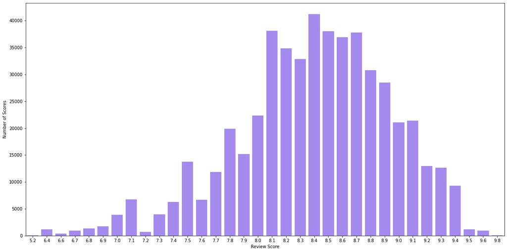

```python
data_plot = df[["Hotel_Name","Average_Score"]]
a4_dims = (20, 10)
fig, ax = plt.subplots(figsize=a4_dims)
reviews_distribution = sns.countplot(ax = ax,x = "Average_Score",data=data_plot, color = '#9D79FF')
reviews_distribution.set(xlabel='Review Score', ylabel='Number of Scores')
```

Also, let's show the distribution of a few scores groups on the pie chart.

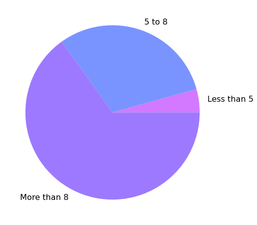

```python
r1 = df.Reviewer_Score[df.Reviewer_Score < 5]
r2 = df.Reviewer_Score[(df.Reviewer_Score >= 5) & (df.Reviewer_Score < 8)]
r3 = df.Reviewer_Score[df.Reviewer_Score >= 8]

values = [r1.count(), r2.count(),r3.count()]
labels = ['Less than 5','5 to 8','More than 8']
colors = ['#D279FF', '#7994FF', '#9D79FF']

fig, ax = plt.subplots(figsize=(8, 8))
pie(values, labels=labels, colors=colors, textprops={'fontsize': 16})

show()
```

### Reviewers Origin

Let's see where the reviewers come from. Later will investigate the relation between nationality and average score left. Also, to achieve hogher accuracy of analysis, let's cut off countries from where there are less than 50 reviews.

```python
origin = df["Reviewer_Nationality"].value_counts()[df["Reviewer_Nationality"].value_counts() > 50]
dt = df.groupby("Reviewer_Nationality").mean()
```

Countries, reviewers from where left the highest scores (**8 and more**):

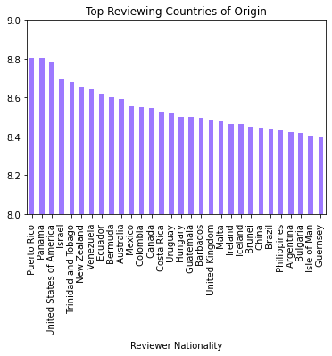

```python
high = dt.loc[origin.index.tolist()]["Reviewer_Score"].sort_values(ascending=False)[:30]
# we don't go above score 9, because there are no average score of more than 9
high.plot(kind="bar",ylim=(8,9),title="Top Reviewing Countries of Origin",  color = '#9D79FF', xlabel='Reviewer Nationality')
```

Countries, reviewers from where left the lowest scores (**6 to 8**). We do not consider countries with average score less than 6 because there is not enough data to make conclusions.

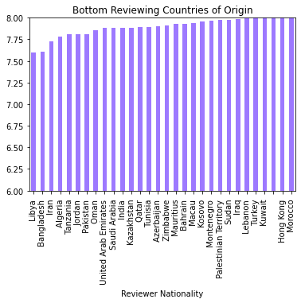

```python
low = dt.loc[origin.index.tolist()]["Reviewer_Score"].sort_values()[:30]
low.plot(kind="bar",ylim=(6,8),title="Bottom Reviewing Countries of Origin", color = '#9D79FF', xlabel='Reviewer Nationality')
```

```python
low_list = []
for idx, val in low.items():
    low_list.append(idx.strip())

high_list = []
for idx, val in high.items():
    high_list.append(idx.strip())
```

```python
world = gpd.read_file('data/world-countries.json')

high_map = alt.Chart(world).project(type = 'equalEarth').mark_geoshape(stroke = 'white').encode(
     fill = alt.condition(
        alt.FieldOneOfPredicate('name', high_list),
        alt.value('#9D79FF'),
        alt.value('lightgray')),
    tooltip = [
        alt.Tooltip('name:N')]
).properties(width = 600, height = 500,  title="High Scores come from:")

low_map = alt.Chart(world).project(type = 'equalEarth').mark_geoshape(stroke = 'white').encode(
     fill = alt.condition(
        alt.FieldOneOfPredicate('name', low_list),
        alt.value('#9D79FF'),
        alt.value('lightgray')),
    tooltip = [
        alt.Tooltip('name:N')]
).properties(width = 600, height = 500, title="Low Scores come from:")

alt.hconcat(high_map,
            low_map
           ).configure_title(fontSize=15, anchor='middle'
           ).properties(background = 'white', padding = 25, title="Origin of the highest and the lowest Scores \n")
```

[interactive chart not shown]

### Word Cloud

My next step is to analyze the text from both positive and negative reviews and display it as a word clouds.  
Below you can see the cloud with the most common words from negative reviews:

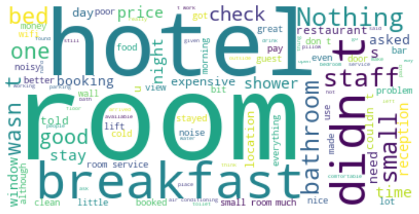

```python
text = " ".join(review for review in df['Negative_Review'])

stopwords = set(STOPWORDS)
stopwords.update(["Nan","Negative","etc","didn't"])

wordcloud = WordCloud(stopwords=stopwords, background_color="white", max_words=100).generate(text)

plt.figure(figsize=(12,10))
plt.imshow(wordcloud, interpolation='bilinear')
plt.axis("off")
plt.show()
```

After looking at cloud we can assume that most of visitors were not satisfied with their rooms, breakfasts and hotels in general.  
Below is the word cloud with positive reviews:

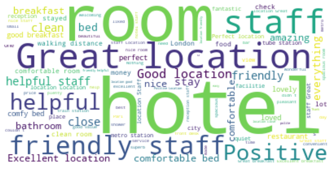

```python
text = " ".join(review for review in df['Positive_Review'])

stopwords = set(STOPWORDS)
stopwords.update(["Nan","Negative","etc"])

wordcloud = WordCloud(stopwords=stopwords, background_color="white", max_words=100).generate(text)

plt.figure(figsize=(12,10))
plt.imshow(wordcloud, interpolation='bilinear')
plt.axis("off")
plt.show()
```

From these results we assume that visitors were satisfied with the location of the hotel, rooms and hotel staff.

### Rewiev date impact on the Score

Let's check the relation between the average hotel rate and the date through the year.

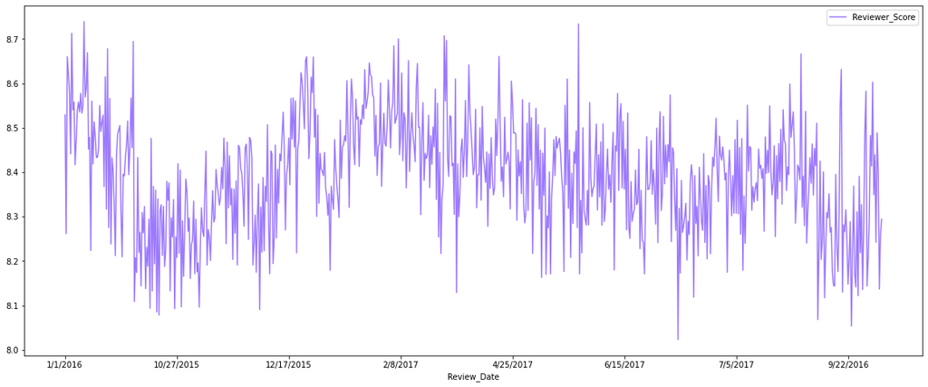

```python
df["Review_Date_Month"] = df["Review_Date"].apply(lambda x: x[5:7])
df[["Review_Date","Reviewer_Score"]].groupby("Review_Date").mean().plot(figsize=(20,8), color = '#9D79FF')
```